# Poetry and Little-Review Network Analysis

Sophia Juliana Hoeller 5116728

2023-07-17

# Introduction:

The “Poetry and the Little Review” Network Analysis aims to examine the relationships between notable modernist authors.

This project is composed by two datasets: a *node* dataset and an *edge* dataset.

The *nodes csv* contains authors, and the *edges csv* contains weighted publication relationships between those authors, which were calculated based on how many times each author appeared with another author in the same journal issue.

It is an undirect dataset, and so connections between elements have no specific directions, therefore it means that the relationships or interactions between elements are bidirectional or symmetric.

## Libraries

```r
library(tidyverse)
```

```r
library(igraph)
library(igraphdata)
library(network)
library(sand)
library(statnet)
library(ergm)
```

## Upload the dataset

```r
#import the node csv
nodes <- read.csv("/Users/sophiahoeller/Downloads/poetry-little-review-nodes.csv")

# Check the contents of the first nodes
head(nodes)
```

```
##                      Id                 Label
## 1 Moody, William Vaughn Moody, William Vaughn
## 2   Baker, Karle Wilson   Baker, Karle Wilson
## 3                 C. Z.                 C. Z.
## 4          Hunt, Violet          Hunt, Violet
## 5         Harris, Frank         Harris, Frank
## 6     Torrence, Ridgely     Torrence, Ridgely
```

```r
# import the edge csv
edges <- read.csv("/Users/sophiahoeller/Downloads/poetry-little-review-edges.csv")

head(edges)
```

```
##                  Source                Target Weight
## 1 Moody, William Vaughn Ficke, Arthur Davison      2
## 2   Baker, Karle Wilson      Stevens, Wallace      3
## 3   Baker, Karle Wilson   Henderson, Alice C.      3
## 4   Baker, Karle Wilson    Bodenheim, Maxwell      2
## 5   Baker, Karle Wilson       Monroe, Harriet      4
## 6   Baker, Karle Wilson  Dresbach, Glenn Ward      2
```

Then, we check if there are missing values, and we can affirm that there aren’t

```r
table(is.na(nodes))
```

```
##
## FALSE
##   782
```

```r
table(is.na(edges))
```

```
##
## FALSE
##  7278
```

```r
#create an undirected graph
set.seed(1)
g <- graph_from_data_frame(edges, vertices = nodes, directed = FALSE)
```

In a network:

- the **nodes** represent the entities ;
- the **edges** represent the connections between nodes in a graph

```r
#set weights

E(g)$weight <- edges$Weight
V(g)$Id <- nodes$Id
```

```r
paste("The number of nodes is: ", vcount(g))
```

```
## [1] "The number of nodes is:  391"
```

```r
paste("The number of edges is: ", ecount(g))
```

```
## [1] "The number of edges is:  2426"
```

# Graphical representation

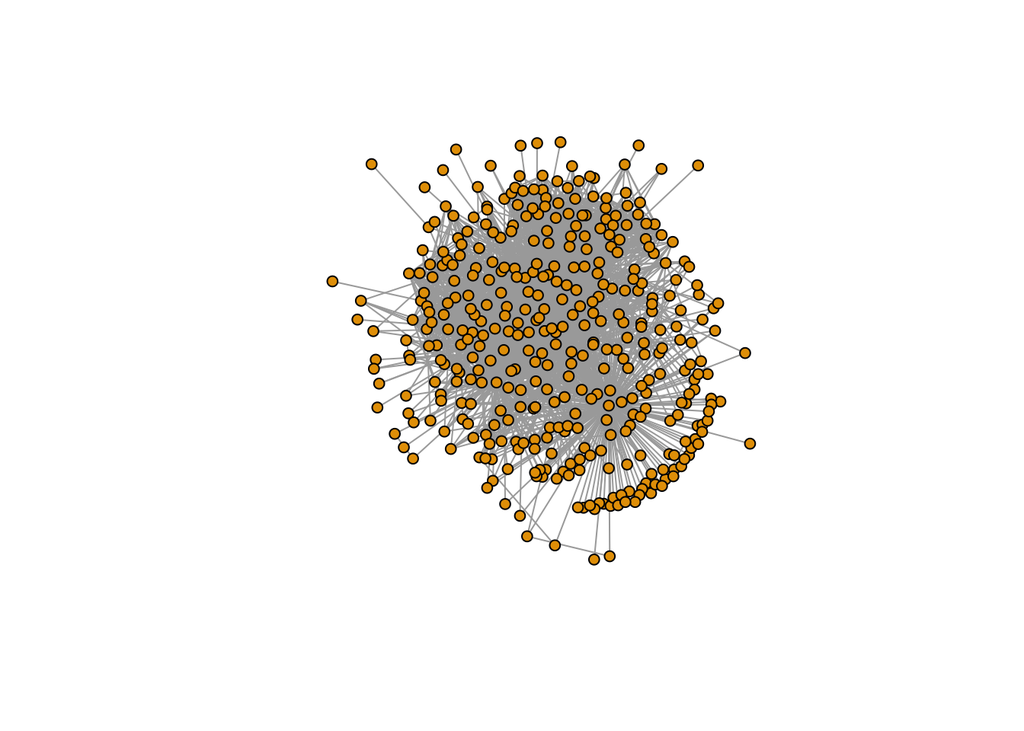

```r
igraph_options(vertex.size=5,edge.arrow.size = 0.5)

plot(g, layout = layout.kamada.kawai, vertex.label = "")
```

As it is shown in the plot, there are nodes that are close and aggregated, which mean that there can be clusters of nodes that interact frequently with each other, which points that are distant form each other may represent less frequent interactions.

Then, we check if the graph is simply and if the edges are weighted.

```r
is.simple(g)
```

```
## [1] TRUE
```

```r
is.weighted(g)
```

```
## [1] TRUE
```

# Centrality

It provides measures that quantify the relative importance of nodes based on their structural positions and interactions with other nodes in the network.

There are many measures of centrality. In this project, we’ll examine *Degree*, *Closeness* and *Betweeness.*

## 1. Degree

The degree of a graph refers to the number of connections/edges that a node has with the other nodes.

Consequently, we check the degree by sorting in a decreasing order, and as we can notice Harriet Monroe has the highest degree.

```r
g_degree = igraph::degree(g)
sort(g_degree, decreasing=TRUE) [1:20]
```

```
##          Monroe, Harriet              Pound, Ezra    Anderson, Margaret C.
##                      256                      146                      141
##      Henderson, Alice C.         Tietjens, Eunice              Lowell, Amy
##                      139                      106                      101
##       Aldington, Richard       Bodenheim, Maxwell       Anderson, Sherwood
##                       94                       85                       83
##                       jh     Fletcher, John Gould       Carnevali, Emanuel
##                       78                       67                       64
##    Ficke, Arthur Davison               Hecht, Ben             Joyce, James
##                       61                       59                       57
##    Foster, George Burman            Soule, George Williams, William Carlos
##                       56                       55                       55
##       Kaun, Alexander S.           Bynner, Witter
##                       54                       50
```

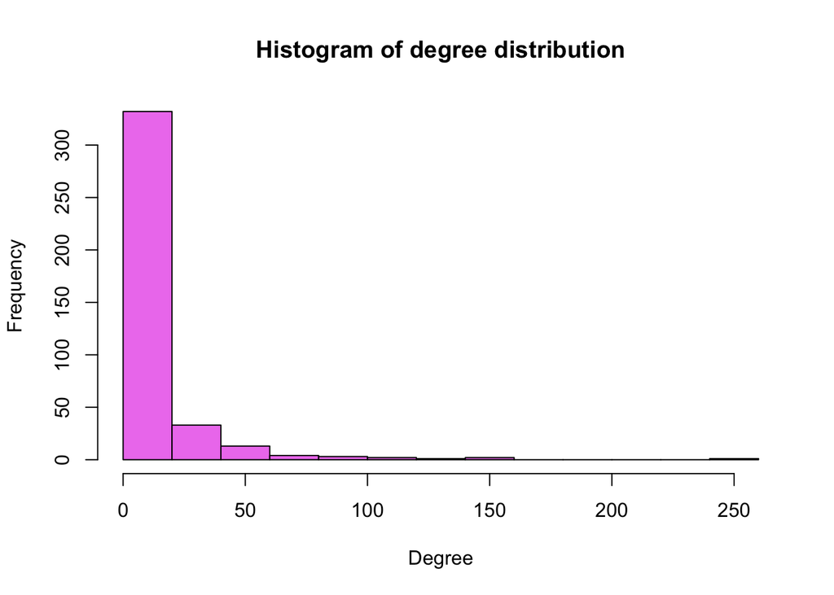

```r
hist(g_degree, xlab="Degree", main="Histogram of degree distribution", col="violet")
```

Then, we plot the graph strength and we can make the same conclusion as before. Graph strength refers to a measure of the influence or importance of a node within a graph or network. It quantifies the extent to which a node affects the flow of information or interactions within the network.

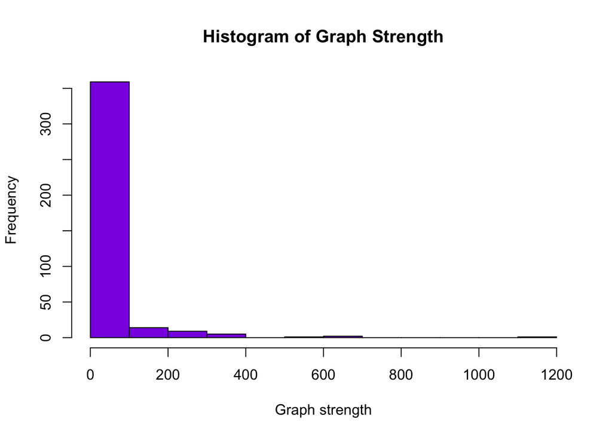

```r
hist(graph.strength(g), xlab="Graph strength", main="Histogram of Graph Strength", col="blueviolet")
```

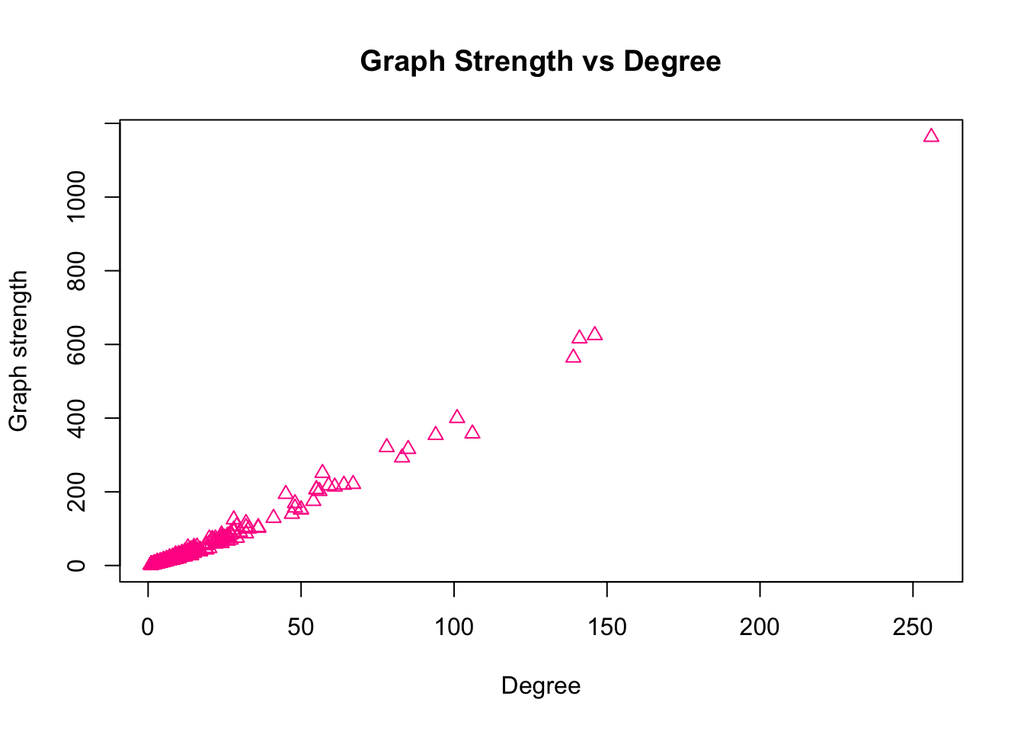

```r
plot(g_degree, graph.strength(g), col="deeppink", xlab="Degree", ylab="Graph strength", pch=2, main="Graph Strength vs Degree")
```

Here, we can observe that degree and graph strength are positively correlated. Higher is the degree of the nodes, higher is the graph strength.

## 2. Closeness

Closeness is a measure of centrality that quantifies the average distance between a node and all other nodes in the graph.

In our analysis, we can affirm that Harriet Monroe has the highest value, therefore it is the central node.

```r
g_close <-igraph :: closeness(g, mode="total")
sort(g_close, decreasing = TRUE)[1:10]
```

```
##       Monroe, Harriet Anderson, Margaret C.   Henderson, Alice C.
##          0.0006997901          0.0006112469          0.0006071645
##    Anderson, Sherwood          Joyce, James            Hecht, Ben
##          0.0006038647          0.0005991612          0.0005966587
##        Symons, Arthur      Saphier, William           Pound, Ezra
##          0.0005945303          0.0005830904          0.0005763689
##         Kilmer, Joyce
##          0.0005727377
```

## 3. Betweeness

*Betweeness* is a measure of centrality that aims to quantify the importance of a node between other nodes in the network. it is an another way to determine the central node.

```r
betw <- igraph::betweenness(g)
sort(betw, decreasing = TRUE)[1:10]
```

```
##       Monroe, Harriet   Henderson, Alice C.           Pound, Ezra
##             26889.849              9150.827              7420.546
## Anderson, Margaret C.      Tietjens, Eunice    Anderson, Sherwood
##              6901.893              4175.347              3807.600
##                    jh           Lowell, Amy    Carnevali, Emanuel
##              3729.368              2942.080              2501.781
##    Aldington, Richard
##              2486.847
```

# Linear vs Poisson Regression

In order to investigate the relationship between the degree distribution of a network and its frequency, we plot two regression models:

1. A *linear regression model* where we check if there is a linear association between the log of the degree and the frequency;
2. A *Poisson regression model*.

```r
degree_dist <- function (g) {
 fd <- table(igraph::degree(g))
 d <- as.numeric(names(fd)) + 1
 list(d = d, fd = fd)
}
```

```r
fd <- degree_distribution(g)
d <- igraph::degree(g)
dd <- degree_dist(g)

(m0 <- lm(log(fd) ~ log(d) , data = dd))
```

```
##
## Call:
## lm(formula = log(fd) ~ log(d), data = dd)
##
## Coefficients:
## (Intercept)       log(d)
##       4.672       -1.070
```

```r
(m1 <- glm(fd ~ log(d), family = poisson, data = dd))
```

```
##
## Call:  glm(formula = fd ~ log(d), family = poisson, data = dd)
##
## Coefficients:
## (Intercept)       log(d)
##       5.141       -1.190
##
## Degrees of Freedom: 54 Total (i.e. Null);  53 Residual
## Null Deviance:       695.8
## Residual Deviance: 45.49     AIC: 214.3
```

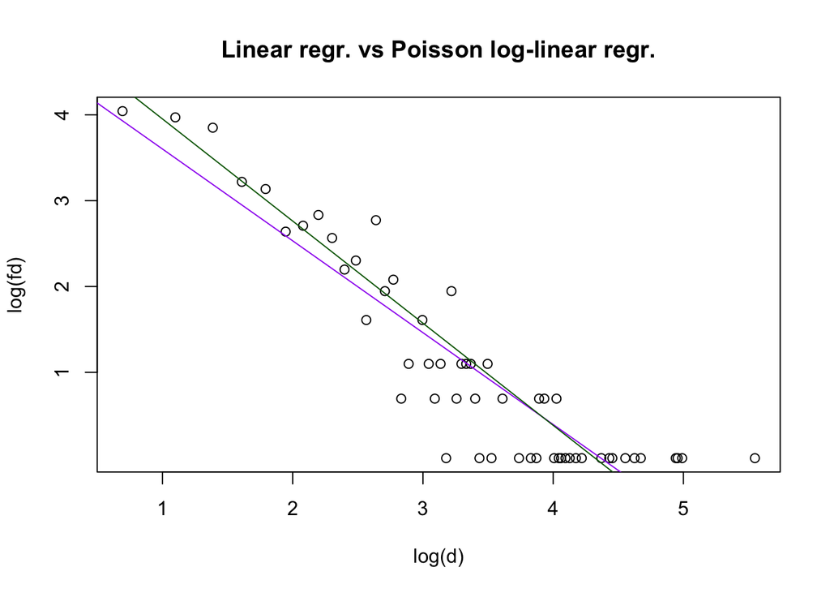

```
## integer(0)
```

```r
with(dd, plot(log(d), log(fd), main="Linear regr. vs Poisson log-linear regr."))+abline(m0$coefficients[1], m0$coefficients[2], col = 'purple')+abline(m1$coefficients[1], m1$coefficients[2], col = 'darkgreen')
```

We can also use the `netstat_dist` function in order to analyse the betweenness centrality distribution.

```r
netstat_dist <- function (s, ...) {
  h <- hist(s, plot=FALSE, ...)
  bin_breaks <- as.vector(stats::filter(h$breaks, c(1,1)/2))
  bin_breaks <- bin_breaks[-length(h$breaks)]
  list(s=bin_breaks[h$counts>0], fs=h$counts[h$counts > 0])

}



bd <- netstat_dist(igraph::betweenness(g), breaks = 100)


(m0 <- lm(log(fs)~log(s), data = bd)) #naive
```

```
##
## Call:
## lm(formula = log(fs) ~ log(s), data = bd)
##
## Coefficients:
## (Intercept)       log(s)
##      8.1212      -0.9609
```

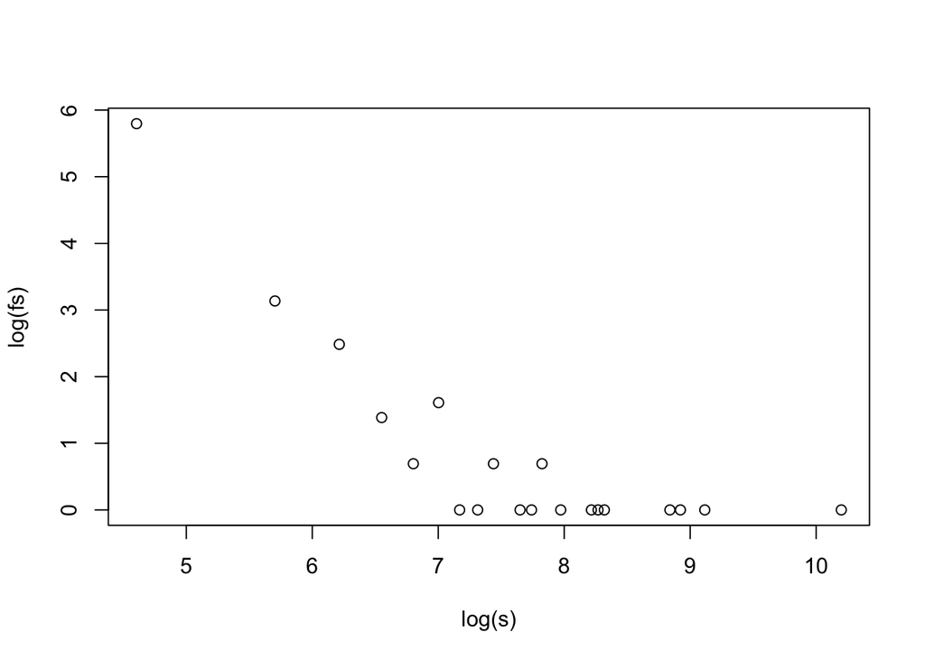

```r
with(bd, plot(log(s), log(fs)))
```

```r
(m1 <- glm(fs~log(s), family = poisson, data = bd))
```

```
##
## Call:  glm(formula = fs ~ log(s), family = poisson, data = bd)
##
## Coefficients:
## (Intercept)       log(s)
##      14.571       -1.916
##
## Degrees of Freedom: 19 Total (i.e. Null);  18 Residual
## Null Deviance:       1728
## Residual Deviance: 38.15     AIC: 97.69
```

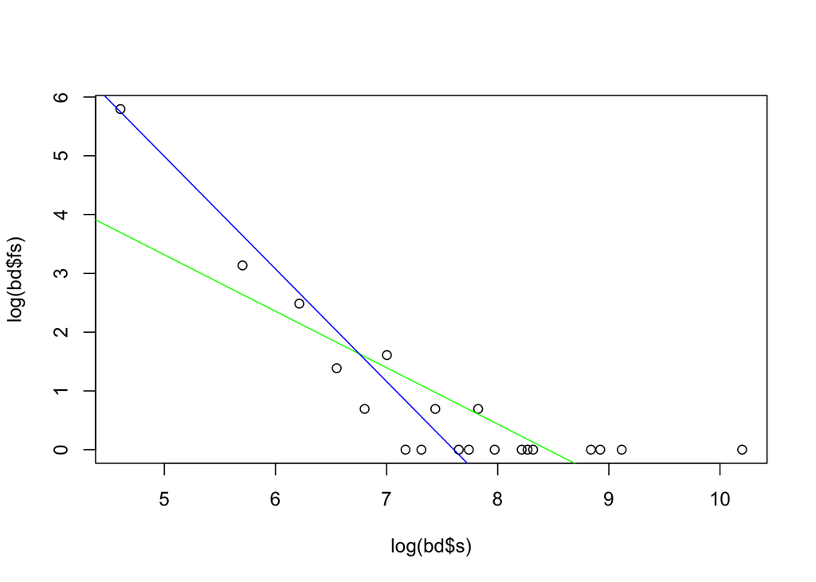

```
## integer(0)
```

```r
plot(log(bd$s),log(bd$fs)) +abline(a=m0$coef[1], b=m0$coef[2], col="green")+abline(a=m1$coef[1], b=m1$coef[2], col="blue")
```

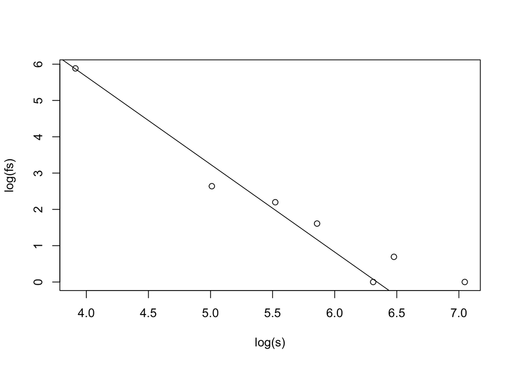

```r
netstat_dist <- function (s, ...) {
  h <- hist(s, plot = FALSE, ...)
  bin_breaks <- as.vector(stats::filter(h$breaks, c(1, 1) / 2))
  bin_breaks <- bin_breaks[-length(h$breaks)]
  list(s = bin_breaks[h$counts > 0], fs = h$counts[h$counts > 0])
}
ds=netstat_dist(graph.strength(g))

gm= glm(fs~log(s), family = poisson, data=ds)
with(ds,plot(log(s), log(fs))); abline(a=gm$coef[1],b=gm$coef[2])
```

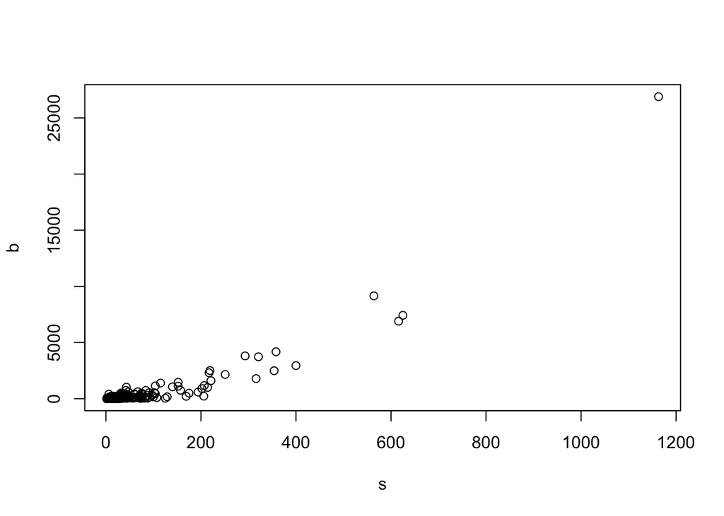

```r
b = igraph::betweenness(g)
s = graph.strength(g)
plot(s,b)
```

This plot shows the relationship between the betweenness and the strength of the nodes. The nodes that are high, represent that we have numerous connection which are significant.

# Graph Structure Analysis

## Diameter

It quantifies the maximum distance or number of edges between two nodes.

```r
diam <- diameter(g)
diam
```

```
## [1] 10
```

The resulting number means that the longest path between any two nodes requires a maximum of 10 link.

## Mean distance

```r
mean_distance(g)
```

```
## [1] 5.408656
```

It shows the average shortest path length.

## Clustering

*Clustering* is a process that consists on identifying groups of nodes that are more densely connected compared to nodes in other groups.

### Transitivity

```r
transitivity(g)
```

```
## [1] 0.2237465
```

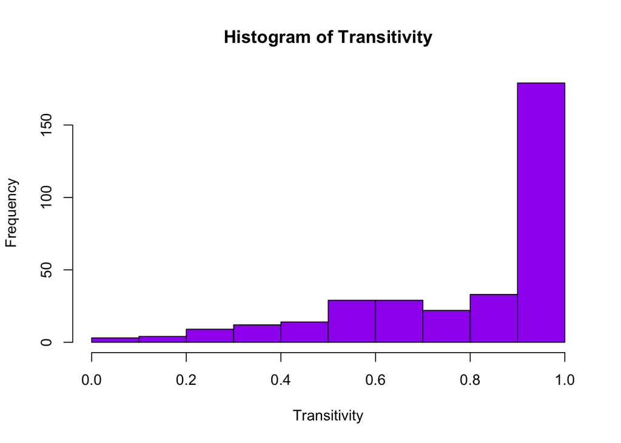

```r
hist(transitivity(g, "local"), col="purple", main="Histogram of Transitivity", xlab="Transitivity")
```

Transitivity is a fundamental concept that measures the tendency of nodes in a network to form triangles or triads.The transitivity coefficient has a range between 0 and 1, where “0” indicates no transitivity and “1” is maximum transitivity.

In this case, the coefficient of transitivity is equal to 0.22, which means that the network is not fully transitive.

### Connectivity

It refers to the reachability of a vertex from every other vertex.

```r
igraph::is.connected(g)
```

```
## [1] TRUE
```

This means that there are no isolated nodes or groups of nodes that are not connected to other nodes in the graph.

### Motifs

Motifs are subgraphs with a certain well-defined structure that are often through to be “frequently occuring” such as: dyads and triads.

```r
dyad_census(g)
```

```
## $mut
## [1] 2426
##
## $asym
## [1] 0
##
## $null
## [1] 73819
```

We have 2426 pairs with mutual connections and. 73819 pairs with no connection

Triad census is a technique used in network analysis to analyze the distribution and frequencies of different types of triads (three-node subgraphs) within a network. It provides a systematic way to quantify the local connectivity patterns and structural properties of networks.

```r
triad_census(g)
```

```
##  [1] 9063265       0  712341       0       0       0       0       0       0
## [10]       0  101114       0       0       0       0    9715
```

## Fast Greedy

We want to examine if there are subset of vertices that are:

- well-connected among themselves
- relatively well-separated from others.

It’s related to the general clustering analysis and so, we have to deal with two popular classes: *hierarchical clustering* and *spectral clustering*

```r
kc <- fastgreedy.community(g)
sizes(kc)
```

```
## Community sizes
##   1   2   3
##  79  91 221
```

It is noticeable that there are 3 communities of different sizes.

```r
kc
```

```
## IGRAPH clustering fast greedy, groups: 3, mod: 0.37
## + groups:
##   $`1`
##    [1] "Moody, William Vaughn"       "Lindsay, Nicholas Vachel"
##    [3] "M. B."                       "Powys, John Cowper"
##    [5] "Dell, Floyd"                 "Jones, Llewellyn"
##    [7] "Simon, Anne"                 "Carter, Huntly"
##    [9] "Stone, Lee A."               "Masseck, Clinton"
##   [11] "Stephens, James"             "Wang Wei"
##   [13] "D. C. W."                    "Lowell, Amy"
##   [15] "Sell, Henry Blackman"        "Nietzsche, Friedrich"
##   [17] "R."                          "Flint, F. S."
##   + ... omitted several groups/vertices
```

```r
fc <- cluster_fast_greedy(g)
head(membership(fc))
```

```
## Moody, William Vaughn   Baker, Karle Wilson                 C. Z.
##                     1                     3                     2
##          Hunt, Violet         Harris, Frank     Torrence, Ridgely
##                     3                     2                     3
```

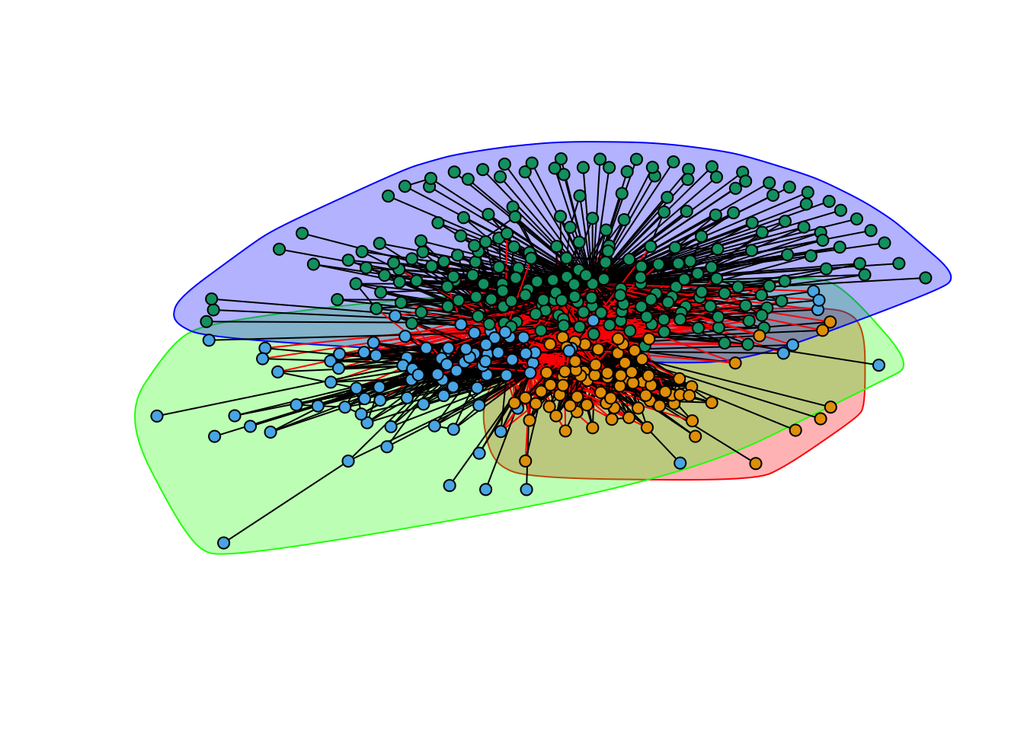

```r
plot(kc, g, vertex.label = "",asp=0.5,vertex.size=3)
```

## Ego network

```r
ia <- order(b, decreasing = TRUE)[1]
V(g)$name[ia]
```

```
## [1] "Monroe, Harriet"
```

```r
tail(sort(b))
```

```
##    Anderson, Sherwood      Tietjens, Eunice Anderson, Margaret C.
##              3807.600              4175.347              6901.893
##           Pound, Ezra   Henderson, Alice C.       Monroe, Harriet
##              7420.546              9150.827             26889.849
```

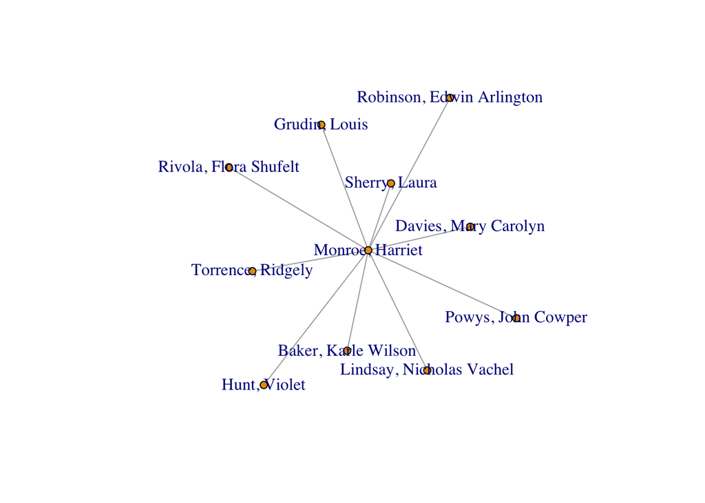

```r
sg <- subgraph.edges(g, E(g)[.inc(ia)][1:10])
plot(sg)
```

# ERGM model

**Exponential random graph models** (ERGM) are models for random graphs which are characterized by the form of their exponential-family distribution.

In an ERGM, the network is represented as a binary adjacency matrix, where each element indicates whether there is a tie or connection between two nodes.

```r
am <- get.adjacency(g, sparse = FALSE)
g1 <- as.network(am, directed = FALSE)
ergm(g1~edges) %>% summary()
```

```
## Starting maximum pseudolikelihood estimation (MPLE):
```

```
## Obtaining the responsible dyads.
```

```
## Evaluating the predictor and response matrix.
```

```
## Maximizing the pseudolikelihood.
```

```
## Finished MPLE.
```

```
## Evaluating log-likelihood at the estimate.
```

```
## Call:
## ergm(formula = g1 ~ edges)
##
## Maximum Likelihood Results:
##
##       Estimate Std. Error MCMC % z value Pr(>|z|)
## edges -3.41537    0.02063      0  -165.5   <1e-04 ***
## ---
## Signif. codes:  0 '***' 0.001 '**' 0.01 '*' 0.05 '.' 0.1 ' ' 1
##
##      Null Deviance: 105698  on 76245  degrees of freedom
##  Residual Deviance:  21502  on 76244  degrees of freedom
##
## AIC: 21504  BIC: 21513  (Smaller is better. MC Std. Err. = 0)
```

- The *Estimate* of the edges is equal to -3.415, this means that the edges have a negative effect on the likelihood.
- The *standard error* is 0.02063
- *MCMC %* is 0, so it means that the estimation uses the MLE;
- *Pr(\>\|z\|)* is very small, therefore it shows a strong evidence against the null hypothesis;
- *AIC and BIC* are 21504 and 21513

Therefore, we can conclude that in the ERGM model the edges have a significant negative effect.